# Applications

None

- 9 Applications
  - 9.1 Flow though an Earth Dam
  - 9.2 Groundwater Flow in a Basin
  - 9.3 Heat Transfer in a Plate

Partially based on [Seepage Analysis](https://github.com/SubhadipN/Conformal_Mapping#seepage-analysis)

## Applications

```python
import numpy as np
import matplotlib.pyplot as plt
```

### Flow through an Earth Dam

In hydrogeology or soil mechanics, the flownet is an important tool for solving two-dimensional irrotational flow problems in the presence of hydraulic structures like dams or sheet pile walls. Initially, the construction of the flownet evolved as a graphical method considering some physical constraints of representing the flow lines and the equipotential (piezometric) lines. Later analytical functions of complex variables, satisfying steady-state flow conditions by following the Laplace equation, were used to find some closed-form solutions for flow domains with simple boundary conditions. However, the process becomes extremely complicated when the flow domain is irregular in shape or unknown altogether. In this scenario, methods of conformal mapping can be used successfully to transform an unconfined flow domain (through an earth dam) or confined flow domain (underneath a concrete dam) into a simple rectangular domain or a half-space plane where the closed-form solutions can be obtained easily. Further, the solutions can be mapped inversely to the original flow domain. The Laplace invariant property of conformal mapping ensures the correctness of the solutions after inverse mapping from the simple domain to the original domain.

Let us define two spatial coordinates, viz., a velocity potential function $\varphi(x,y)$ and a stream function $\psi(x,y)$. $\varphi(x,y)$ and $\psi(x,y)$ are chosen such that they satisfy the governing Laplace equation of the steady-state flow, i.e., $\nabla^2 \varphi(x,y) = 0$ and $\nabla^2 \psi(x,y) = 0$. The two functions $\varphi(x,y)$ and $\psi(x,y)$ are conjugate harmonic (i.e., they follow the Cauchy-Riemann equation), meaning that the two families of curves given by $\varphi(x,y) = \mathrm{constant}$ and $\psi(x,y) = \mathrm{constant}$ represent mutually perpendicular trajectories. Let us consider two complex planes $z$ and $w$, respectively, such that $$z=x+\mathrm{i}y\quad\mathrm{and}\quad w=\varphi+\mathrm{i}\psi\quad\mathrm{with\quad i}=\sqrt{-1} \tag{1}$$ Now, the Kozeny's solution for flow through the earth dams, as shown in Figure 1(b) can be obtained using the following simple transformation $$z = Cw^2\quad\Rightarrow x+iy = C(\varphi^2+i2\varphi\psi-\psi^2) \tag{2}$$ $$\therefore x = C(\varphi^2-\psi^2) \quad \mathrm{and} \quad y = 2C\varphi\psi\tag{3}$$ where, $C$ is a constant, depending on the boundary conditions of the problem. Now, along the free surface CDE (commonly known as the phreatic line or line of seepage), $\psi=q$ and $\varphi=-ky$, where $k$ is the coefficient of hydraulic conductivity (or the coefficient of conductivity) of the soil. Therefore, the second formula of Equation (3) yields $$C=-\dfrac{1}{2kq}\tag{4}$$ The equation for the line of seepage, referred to as Kozeny's basic parabola, can be obtained as $$x = -\dfrac{1}{2kq}(\varphi^2-\psi^2) = -\dfrac{1}{2kq}(k^2y^2-q^2) = \dfrac{1}{2} \left(\dfrac{q}{k}-\dfrac{k}{q}y^2 \right) \tag{5}$$ It should be noted that the real upstream slope of the dam or face BCH (as shown in Figure 1(a)) is modified as a parabola, face B'C'H' in the $z$-plane (as shown in Figure 1(b)). This is in anticipation of the shape of the obtained flownets in the $z$-plane (refer to Figure 2), and correction should be made to account for this discrepancy. The focal distance $x_0$ can be estimated by putting $y=0$ at equation 5 as $$x_0=\dfrac{q}{2k}\quad\Rightarrow q=2kx_0 \tag{6}$$ Therefore, Kozeny's basic parabola can be expressed as $$x = \dfrac{1}{2}\left( 2x_0-\dfrac{y^2}{2x_0}\right) = x_0-\dfrac{y^2}{4x_0} \tag{7}$$ Here, the value of $x_0$ can be estimated by considering the coordinate of the point $C (x_C,y_C)$ from Figure 1(a) as $$x_0 = 0.5 \left( x_C+\sqrt{x_C^2+y_C^2} \right); \quad x_C=h_w; \quad y_C=-b_d+f+0.5h_w(b_d-t_d)/h_d \tag{8}$$ Finally, the complex transformation can be expressed by using Equations (4) and (6) as $$z=f(w)=-\dfrac{w^2}{4k^2x_0}\tag{9}$$

In the figure below see (a) realistic geometric shape of an earth dam in $z$-plane, (b) modified geometric shape of an earth dam in $z$-plane, (c) boundary conditions of flownets in $w$-plane

[figure not shown]

Consider an earth dam with a height equal to $20\ \mathrm{m}$, a top width equal to $12\ \mathrm{m}$, a bottom width equal to $32\ \mathrm{m}$, and the filter width equal to $6\ \mathrm{m}$. The height of the water level is $19\ \mathrm{m}$, and the coefficient of permeability of the homogenous isotropic soil is $3.5\times 10^{-8}\ \mathrm{m/s}$. The Python code below yields a visualization of the isopotentials and streamlines.

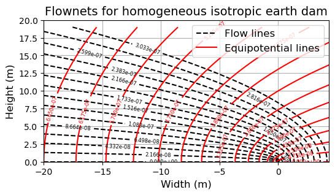

```python
K = 3.5e-8         # Hydraulic conductivity (m/s)
hd = -20           # Height of the dam (m)
hw = -19           # Height of the water level (m)
twd = 12           # Top width of the dam (m)
fw = 6             # Width of the filter (m)
bd = 32            # Bottom width of the dam (m)
fl = 15

hwK = hw*K
C = -bd+fw+0.5*(bd-twd)*hw/hd
xo = 0.5*(C+np.sqrt(C**2+hw**2))
q = 2*K*xo
Q0 = hwK/np.sqrt(-hd)
C = -1/(2*K*q)
xgrid = np.linspace(hd,xo,51)
ygrid = np.linspace(0,-hw,51)
[x,y] = np.meshgrid (xgrid,ygrid)
z = x + 1j*y
w = np.sqrt(z)
P = -np.conj(Q0)*w
phi = np.real(P); psi = np.imag(P)

fig, ax = plt.subplots(figsize=(6, 3))
levels = np.linspace(0,q,fl)
C = plt.contour (x,y,phi,50,levels = levels, colors='black',linestyles='dashed')
plt.clabel(C, inline=True, fontsize=6, fmt = '%5.3e')
levels = np.linspace(0,-hwK,fl)
C = plt.contour (x,y,psi,50,levels = levels, colors='red');
plt.clabel(C, inline=True, fontsize=6, fmt = '%5.3e')
plt.xlim ([hd,xo]); plt.ylim([0,-hd])
plt.xlabel('Width (m)',fontsize=12)
plt.ylabel('Height (m)',fontsize=12)
plt.title('Flownets for homogeneous isotropic earth dam',fontsize=14)
plt.grid()
plt.plot ([hd-1,hd],[-1,0],'k',linestyle='dashed',label='Flow lines')
plt.plot ([hd-1,hd],[-1,0],'r',label='Equipotential lines')
plt.legend(loc ='upper right',fontsize=12)
plt.show()
```

Further examples dealing with concrete gravity dams and sheet piles, programmed in MATLAB, can be found at the web-site [Seepage Analysis](https://github.com/SubhadipN/Conformal_Mapping#seepage-analysis) .

### Groundwater Flow in a Basin

Regional groundwater flow is very much influenced by basin topography. A model for the simple 2D setting in a single basin, or better half-basin was set up and solved analytically by the Canadian hydrogeologist Joszef Toth (1933-). The sketch below depits a vertical cross-section through an isotropic and homogeneousaquifer, and its mathematical formulation in terms of a differential equation and boundary conditions.

[figure not shown]

Groundwater flow is determined by Darcy's Law $ \pmb{v}=-K \cdot \nabla h$. When combined with the equation of mass conservation $-\nabla \cdot \pmb{v} =0 $ the Laplace equation results. The variable of hydraulic head $h$ that plays the roll of the potential fulfils the Laplace equation, i.e is a harmonic function. The analytic solution was derived for the hydraulic head: $$ h(x,y) = y_0 + cx + \sum_{n=0}^{\infty} \frac {\cos((2n+1)\pi x/s) \cosh((2n+1)\pi y/s)}{(2n+1)^2\pi^2 \cosh((2n+1) \pi y_0 )/ s} $$ Hydraulic head is a proxy for the real potential. For a homogeneous and isotropic aquifer the real potential can be expressed as $\Phi = Kh$, where $K$ denotes hydraulic conductity. The streamfunction can be expressed by: $$ \Psi(x,y) = K \sum_{n=0}^{\infty} \frac {\sin((2n+1)\pi x/s) \sinh((2n+1)\pi y/s)}{(2n+1)^2\pi^2 \sinh((2n+1) \pi y_0 )/ s} $$ Hydraulic head is a proxy for the real potential. Using the identities for $z=x+iy$: $$ \cos(x) \cosh(y) = \cos(x) \cos(iy) = \cos(x+iy) + \sin(x) \sin(iy) = \cos(z) -i \sin(x) \sinh(y)$$ we can write the analytical solution as a complex potential: $$ \Phi(z) = K(y_0 + cx + \sum_{n=0}^{\infty} \frac {\cos((2n+1)\pi z/s)}{(2n+1)^2\pi^2 \cosh((2n+1) \pi y_0 )/ s}) $$ The advantage is that with this formulation both potential and streamfunction are given, which allows an easy and accurate visualization of streamlines.

However the solution is given by an infinite sum. In the program the terms of the summation are added sequentially until the added term falls below a predefined accuracy $\epsilon$. In any case not more than 100 terms are considered. In the code below this is programmed by a *while*-loop.

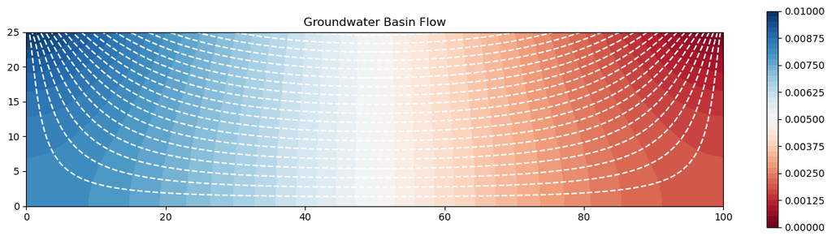

```python
s = 100.                                     # length in horizontal direction
y0 = 25.                                     # depth in vertical direction
c = 0.01                                     # groundwater head slope top
eps = 1e-7                                   # accuracy
N = 100                                      # max. length of summation

x = np.linspace(0,s,100); y = np.linspace(0,y0,25)
X,Y = np.meshgrid (x,y); Z = X + 1.j*Y       # complex mesh

deltax = np.Inf; deltay = np.Inf; n = 0
Phi = 0*Z; Phi0 = 0*Z
while ((deltax > eps) or (deltay > eps)) and (n < N):
    hn = (n+n+1)*np.pi
    hh = hn*hn*np.cosh(hn*y[-1]/s)
    Phi = Phi + np.cos(hn*Z/s)/hh
    deltax = np.amax(np.abs(np.real(Phi-Phi0)))
    deltay = np.amax(np.abs(np.imag(Phi-Phi0)))
    Phi0 = Phi; n = n+1

fig, ax = plt.subplots(figsize=(16, 4))
plt.contourf (X,Y,0.5*c+4*c*np.real(Phi),40,cmap='RdBu')
plt.colorbar()

plt.contour (X,Y,np.imag(Phi),20,colors='white')
ax.set_title('Groundwater Basin Flow')
ax.set_aspect('equal', adjustable='box')
plt.show()
```

The following figure shows a typical situation of groundwater flow in a cross-section from the mountains to a valley. The setting in the field is not as simple as in the idealized situation delt by Toth. On the right a more complex setting is depicted that includes local recirculation patterns near the earth surface.

[figure not shown]

The figure was taken from [Groundwater Flow System](https://ontariograinfarmer.ca/2021/04/01/water-management-9/5) .

### Heat Transfer in a Plate

Heat transfer in a plate can be computed similarly. In comparison to the previous application here the variable to be computed is the temperature $T$. Heat flow is determined by Fourier's Law $ \pmb{q}=- k \cdot \nabla T$. When combined with the equation of energy conservation $-\nabla \cdot \pmb{q} = 0$, the Laplace equation results. The variable of temperature $T$ that plays the roll of the potential fulfils the Laplace equation, i.e is a harmonic function. Assume that the entire plate has a constant temperature $T_0$ at left, right and bottom boundaries. On the top boundary a sinusoidial temperature distribution is required with $T_0$ at the left and right sides and a maximum value of $T_1$ in the center. The solution for the temperature is given by (Holman, 1981):

$$ T(x,y) = T_0 + (T_1-T_0) \frac {\sin((\pi x/s) \sinh(\pi y/s)}{\sinh(\pi y_0 )/ s} $$

The product in the numerator can be simplified as in example 9.2. Moreover we perform the extension to the complex potential.

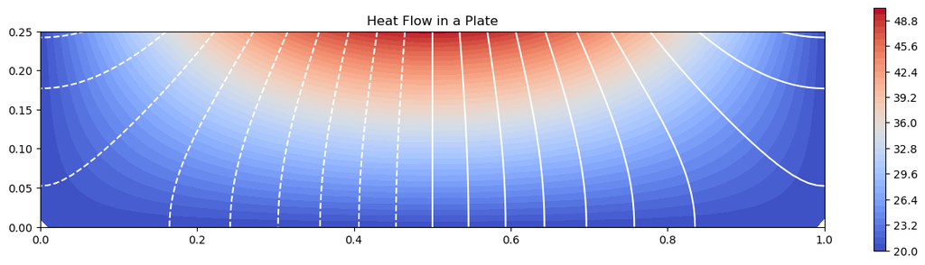

```python
s = 1.                                     # length in horizontal direction
y0 = .25                                   # depth in vertical direction
T1 = 50                                    # maximum temperature
T0 = 20                                    # ambient temperature

x = np.linspace(0,s,100); y = np.linspace(0,y0,25)
X,Y = np.meshgrid (x,y); Z = X + 1.j*Y       # complex mesh
Phi = -(T1-T0)*np.cos(np.pi*Z/s)/np.sinh(np.pi*y[-1]/s)

fig, ax = plt.subplots(figsize=(16, 4))
plt.contourf (X,Y,T0+np.imag(Phi),40,cmap='coolwarm')
plt.colorbar()

plt.contour (X,Y,np.real(Phi),20,colors='white')
ax.set_title('Heat Flow in a Plate')
ax.set_aspect('equal', adjustable='box')
plt.show()
```

If there is a constant temperature $T_1$ at the top of the plate the solution can be expressed by an infinite series:

$$ T(x,y) = T_0 + (T_1-T_0) \sum_{n=0}^{\infty} \frac {\sin((2n+1)\pi x/s) \sinh((2n+1)\pi y/s)}{(2n+1)^2\pi^2 \sinh((2n+1) \pi y_0 )/ s} $$